# Recalling Words

Wilcoxon Test

Week 4

## Background

Many teachers and other educators are interested in understanding how to best deliver new content to students. In general, they have two choices of how to do this.

1. The Meshed Approach
   - Deliver new content while simultaneously reviewing previously understood content.
2. The Before Approach
   - Deliver new content after fully reviewing previously understood content.

A study was performed to determine whether the *Meshed* or *Before* approaches to delivering content had any positive benefits on memory recall.

## Questions and Hypotheses

What type of learning is a better method, Meshed or Before? I think that Meshed learning is better compared to Before learning.

$$H_0: \text{Before} = 0$$

$$H_a: \text{Meshed} > 0$$

## Data Analysis

```r
friendly <- dplyr::filter(Friendly, condition %in% c("Meshed", "Before"))

friendly %>%
    group_by(condition) %>%
    summarise(minimum = min(correct),
              average = mean(correct),
              median = median(correct),
              maximum = max(correct)) %>%
    pander()
```

| condition | minimum | average | median | maximum |
| --- | --- | --- | --- | --- |
| Before | 24 | 36.6 | 39 | 40 |
| Meshed | 30 | 36.6 | 36.5 | 40 |

First step in analysis is analyzing number. This is done by Numerical Summaries. First filter to the condition of learning. Then create a table with the minimum, average, median, and maximum. These numbers help figure out the values for recalling information.

## Graphical Summaries

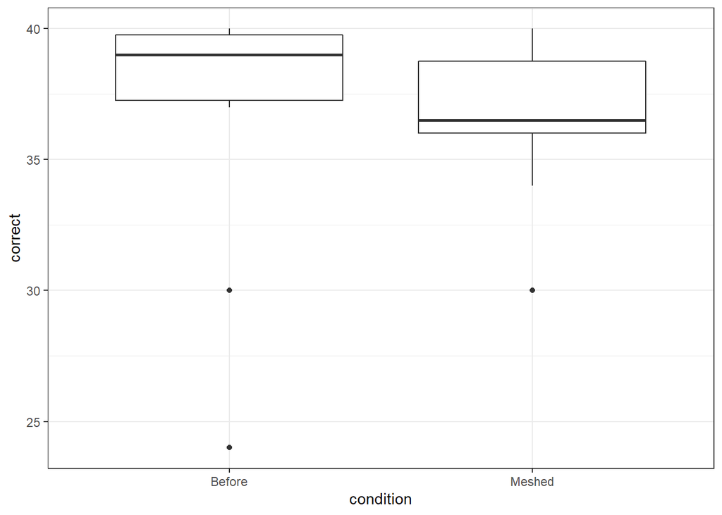

```r
ggplot(friendly, aes(x = condition, y = correct)) + geom_boxplot() + theme_bw()
```

The graph shows us that the recall rate is higher with before method then meshed. Although there are more outliers when using the Before method.

## Interpretation

```r
wilcox.test(correct ~ condition, data = friendly, mu = 0, alternative = "greater", paired = TRUE, conf.level = 0.95) %>%
    pander()
```

Wilcoxon signed rank test with continuity correction: `correct` by `condition`

| Test statistic | P value | Alternative hypothesis |
| --- | --- | --- |
| 18 | 0.528 | greater |